# Me: Chris Hausler

# Today - Pandas and Scikit-Learn

## And a lot of firsts

- first MPUG meeting... Hi
- first presentation using IPython Notebook

## Python Data Analysis Library (pandas)

pandas is an open source, BSD-licensed library providing high-performance, easy-to-use data structures and data analysis tools for the Python programming language.  
**Creates somthing similar to R DataFrames.. but better**

### I think it's great, but I'm still a bit clumsy with it .. also the doco is still a little hit and miss

#### Some imports

```python
import warnings
warnings.filterwarnings("ignore", category=DeprecationWarning)
warnings.filterwarnings("ignore", category=UserWarning)
```

```python
import numpy as np
import pandas as pd
import pylab as plt
import matplotlib
%matplotlib inline
pd.__version__
```

```
'0.13.1'
```

### `pandas` has two main data structures: `Series` and `DataFrame`

## Series - Like a one dimensional array but better

```python
values = [5,3,4,8,2,9]
vals = pd.Series(values)
vals
```

```
0    5
1    3
2    4
3    8
4    2
5    9
dtype: int64
```

Each value is now associated with an *index*. The index itself is an object of class `Index` and can be manipulated directly.

```python
vals.index
```

```
Int64Index([0, 1, 2, 3, 4, 5], dtype='int64')
```

```python
vals.values
```

```
array([5, 3, 4, 8, 2, 9])
```

```python
vals * 2.5
```

```
0    12.5
1     7.5
2    10.0
3    20.0
4     5.0
5    22.5
dtype: float64
```

We can give named indexes

```python
vals2 = pd.Series(values, index=['tom','sally','jeff','george','pablo','florence'])
vals2
```

```
tom         5
sally       3
jeff        4
george      8
pablo       2
florence    9
dtype: int64
```

And use these to get the data we want

```python
vals2[['florence','tom']]
```

```
florence    9
tom         5
dtype: int64
```

```python
vals2[['florence','tom','kate']]
```

```
florence     9
tom          5
kate       NaN
dtype: float64
```

Dealing with missing values

```python
vals3 = vals2[['tom','sally','pablo','florence','ricky','katrin']]
vals3
```

```
tom          5
sally        3
pablo        2
florence     9
ricky      NaN
katrin     NaN
dtype: float64
```

Get rid of them

```python
vals3.dropna()
```

```
tom         5
sally       3
pablo       2
florence    9
dtype: float64
```

Fill them with a value

```python
vals3.fillna(0)
```

```
tom         5
sally       3
pablo       2
florence    9
ricky       0
katrin      0
dtype: float64
```

Fill them with a calculated value

```python
vals3.fillna(vals3.mean())
```

```
tom         5.00
sally       3.00
pablo       2.00
florence    9.00
ricky       4.75
katrin      4.75
dtype: float64
```

Use a function like forward fill

```python
vals3.fillna(method='ffill')
```

```
tom         5
sally       3
pablo       2
florence    9
ricky       9
katrin      9
dtype: float64
```

A handy way to get a picture of our data

```python
vals3.describe()
```

```
count    4.000000
mean     4.750000
std      3.095696
min      2.000000
25%      2.750000
50%      4.000000
75%      6.000000
max      9.000000
dtype: float64
```

## DataFrame - Like a 2D array... with bells and whistles

```python
vals.index=pd.Index(['tom','sally','pablo','florence','ricky','katrin'])
vals3=vals3[['tom','sally','pablo','florence','billy','katrin']]
```

```python
# create a dataframe
dat = pd.DataFrame({'orig':vals,'new':vals3})
dat
```

|  | new | orig |
| --- | --- | --- |
| billy | NaN | NaN |
| florence | 9 | 8 |
| katrin | NaN | 9 |
| pablo | 2 | 4 |
| ricky | NaN | 2 |
| sally | 3 | 3 |
| tom | 5 | 5 |

7 rows × 2 columns

Check for nulls

```python
dat.isnull()
```

|  | new | orig |
| --- | --- | --- |
| billy | True | True |
| florence | False | False |
| katrin | True | False |
| pablo | False | False |
| ricky | True | False |
| sally | False | False |
| tom | False | False |

7 rows × 2 columns

Drop rows with nulls

```python
dat.dropna()
```

|  | new | orig |
| --- | --- | --- |
| florence | 9 | 8 |
| pablo | 2 | 4 |
| sally | 3 | 3 |
| tom | 5 | 5 |

4 rows × 2 columns

## Timeseries with pandas DataFrames - a winning combination

Data from google trends.. what correlates (+ve & -ve) with the search term *Hipster*

#### Read hipster correlations from a csv file

Pandas supports many file formats for read and write including + *csv* + *json* + *pickle* + *the clipboard*

```python
hipster = pd.read_csv('hipster.csv')
hipster[:10]
```

|  | Date | hipster | modcloth | gumtree perth |
| --- | --- | --- | --- | --- |
| 0 | 2004-01-04 | -0.976 | -0.817 | -0.844 |
| 1 | 2004-01-11 | -0.816 | -0.817 | -0.844 |
| 2 | 2004-01-18 | -0.837 | -0.817 | -0.844 |
| 3 | 2004-01-25 | -0.976 | -0.817 | -0.844 |
| 4 | 2004-02-01 | -0.722 | -0.817 | -0.844 |
| 5 | 2004-02-08 | -0.795 | -0.817 | -0.844 |
| 6 | 2004-02-15 | -0.723 | -0.817 | -0.844 |
| 7 | 2004-02-22 | -0.713 | -0.817 | -0.844 |
| 8 | 2004-02-29 | -0.786 | -0.817 | -0.844 |
| 9 | 2004-03-07 | -0.675 | -0.817 | -0.844 |

10 rows × 4 columns

Set the index to a datetime

```python
hipster = hipster.set_index(pd.DatetimeIndex(hipster.pop('Date')))
hipster[:10]
```

|  | hipster | modcloth | gumtree perth |
| --- | --- | --- | --- |
| 2004-01-04 | -0.976 | -0.817 | -0.844 |
| 2004-01-11 | -0.816 | -0.817 | -0.844 |
| 2004-01-18 | -0.837 | -0.817 | -0.844 |
| 2004-01-25 | -0.976 | -0.817 | -0.844 |
| 2004-02-01 | -0.722 | -0.817 | -0.844 |
| 2004-02-08 | -0.795 | -0.817 | -0.844 |
| 2004-02-15 | -0.723 | -0.817 | -0.844 |
| 2004-02-22 | -0.713 | -0.817 | -0.844 |
| 2004-02-29 | -0.786 | -0.817 | -0.844 |
| 2004-03-07 | -0.675 | -0.817 | -0.844 |

10 rows × 3 columns

Now load the anti-Hipster data

```python
not_hipster = pd.read_csv('negative-hipster.csv')
not_hipster = not_hipster.set_index(pd.DatetimeIndex(not_hipster.pop('Date')))
```

```python
not_hipster[:10]
```

|  | yellow pages | windows installer | techno |
| --- | --- | --- | --- |
| 2004-01-04 | 1.341 | 0.668 | 0.871 |
| 2004-01-11 | 1.239 | 1.000 | 1.122 |
| 2004-01-18 | 1.022 | 0.768 | 1.053 |
| 2004-01-25 | 0.923 | 0.943 | 0.807 |
| 2004-02-01 | 0.904 | 0.799 | 0.612 |
| 2004-02-08 | 0.786 | 0.613 | 0.614 |
| 2004-02-15 | 0.729 | 0.956 | 0.391 |
| 2004-02-22 | 0.537 | 0.667 | 1.124 |
| 2004-02-29 | 0.534 | 1.415 | 1.078 |
| 2004-03-07 | 0.229 | 0.220 | 1.918 |

10 rows × 3 columns

Check the values of one column

```python
hipster.hipster.head()
```

```
2004-01-04   -0.976
2004-01-11   -0.816
2004-01-18   -0.837
2004-01-25   -0.976
2004-02-01   -0.722
Name: hipster, dtype: float64
```

Check another, but get them as an `numpy.ndarray`

```python
hipster['gumtree perth'].values[:20]
```

```
array([-0.844, -0.844, -0.844, -0.844, -0.844, -0.844, -0.844, -0.844,
       -0.844, -0.844, -0.844, -0.844, -0.844, -0.844, -0.844, -0.844,
       -0.844, -0.844, -0.844, -0.844])
```

View the data types, they don't need to be homogenous

```python
hipster.dtypes
```

```
hipster          float64
modcloth         float64
gumtree perth    float64
dtype: object
```

Joins on indexes are easy!

```python
trend = hipster.join(not_hipster, how='inner')
trend.head()
```

|  | hipster | modcloth | gumtree perth | yellow pages | windows installer | techno |
| --- | --- | --- | --- | --- | --- | --- |
| 2004-01-04 | -0.976 | -0.817 | -0.844 | 1.341 | 0.668 | 0.871 |
| 2004-01-11 | -0.816 | -0.817 | -0.844 | 1.239 | 1.000 | 1.122 |
| 2004-01-18 | -0.837 | -0.817 | -0.844 | 1.022 | 0.768 | 1.053 |
| 2004-01-25 | -0.976 | -0.817 | -0.844 | 0.923 | 0.943 | 0.807 |
| 2004-02-01 | -0.722 | -0.817 | -0.844 | 0.904 | 0.799 | 0.612 |

5 rows × 6 columns

We can check the column names and values

```python
trend.columns
```

```
Index([u'hipster', u'modcloth', u'gumtree perth', u'yellow pages', u'windows installer', u'techno'], dtype='object')
```

```python
trend.values
```

```
array([[-0.976, -0.817, -0.844,  1.341,  0.668,  0.871],
       [-0.816, -0.817, -0.844,  1.239,  1.   ,  1.122],
       [-0.837, -0.817, -0.844,  1.022,  0.768,  1.053],
       ...,
       [ 1.142,  1.175,  1.394, -1.69 , -1.77 , -1.836],
       [ 1.187,  1.221,  1.403, -1.706, -1.752, -1.796],
       [ 1.514,  1.216,  1.365, -1.72 , -1.701, -1.883]])
```

Filtering on date ranges is simple

```python
trend['2012-01-01':].head()
```

|  | hipster | modcloth | gumtree perth | yellow pages | windows installer | techno |
| --- | --- | --- | --- | --- | --- | --- |
| 2012-01-01 | 1.411 | 1.192 | 1.774 | -1.077 | -1.134 | -1.285 |
| 2012-01-08 | 1.513 | 1.111 | 1.579 | -0.995 | -1.183 | -1.189 |
| 2012-01-15 | 1.523 | 1.427 | 1.613 | -1.027 | -1.161 | -1.337 |
| 2012-01-22 | 1.600 | 1.490 | 1.514 | -1.140 | -1.177 | -1.345 |
| 2012-01-29 | 1.459 | 1.561 | 1.511 | -1.046 | -1.224 | -1.233 |

5 rows × 6 columns

```python
trend['2012-01-01': '2013-01-01'].tail(3)
```

|  | hipster | modcloth | gumtree perth | yellow pages | windows installer | techno |
| --- | --- | --- | --- | --- | --- | --- |
| 2012-12-16 | 1.645 | 1.175 | 1.407 | -1.433 | -1.515 | -1.687 |
| 2012-12-23 | 1.591 | 1.695 | 1.625 | -1.698 | -1.655 | -1.504 |
| 2012-12-30 | 1.596 | 1.515 | 1.868 | -1.515 | -1.598 | -1.674 |

3 rows × 6 columns

We can also grab a single date, or a subset of columns

```python
trend.ix['2012-01-01', ['hipster', 'modcloth']]
```

```
hipster     1.411
modcloth    1.192
Name: 2012-01-01 00:00:00, dtype: float64
```

Or do some boolean filtering

```python
trend[trend.techno < 0].head()
```

|  | hipster | modcloth | gumtree perth | yellow pages | windows installer | techno |
| --- | --- | --- | --- | --- | --- | --- |
| 2004-04-11 | -0.510 | -0.817 | -0.844 | 0.521 | 0.301 | -0.270 |
| 2006-01-29 | -0.838 | -0.817 | -0.844 | 1.421 | 1.309 | -0.081 |
| 2006-06-25 | -0.799 | -0.817 | -0.833 | 1.142 | 1.458 | -0.070 |
| 2010-01-24 | -0.454 | -0.183 | -0.107 | -0.017 | 0.053 | -0.010 |
| 2010-01-31 | -0.381 | -0.276 | -0.142 | 0.187 | 0.116 | -0.044 |

5 rows × 6 columns

Plotting is built in and easier for dates than matplotlib

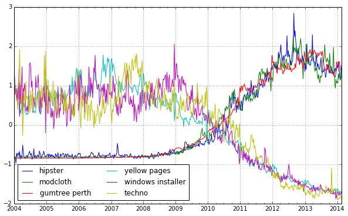

```python
_ = trend.plot(figsize=(10, 6))
_ = plt.legend(loc='best', ncol=2)
```

We can also do it for a single column

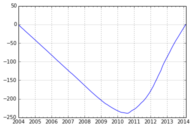

```python
_ = trend.hipster.cumsum().plot()
```

Or split the columns out to subplots

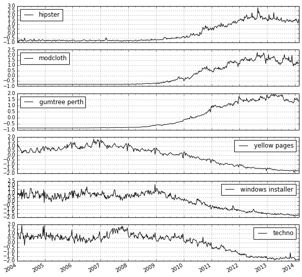

```python
axs = trend.plot(subplots=True, figsize=(10, 10))
```

Resampling data is also straight forward.

```python
# resample by month
trend.resample('M', how='mean').head()
```

|  | hipster | modcloth | gumtree perth | yellow pages | windows installer | techno |
| --- | --- | --- | --- | --- | --- | --- |
| 2004-01-31 | -0.90125 | -0.817 | -0.844 | 1.13125 | 0.84475 | 0.96325 |
| 2004-02-29 | -0.74780 | -0.817 | -0.844 | 0.69800 | 0.89000 | 0.76380 |
| 2004-03-31 | -0.78950 | -0.817 | -0.844 | 0.35650 | 0.73125 | 1.09175 |
| 2004-04-30 | -0.70400 | -0.817 | -0.844 | 0.48125 | 0.89125 | 0.41950 |
| 2004-05-31 | -0.81820 | -0.817 | -0.844 | 0.34780 | 0.62040 | 0.72860 |

5 rows × 6 columns

and Here by year, but one can do business day, week, month, quarter annual and a bunch of others

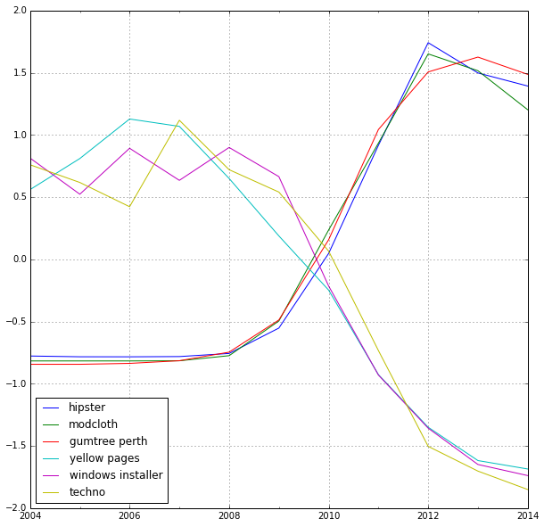

```python
# resample by year
_ = trend.resample('A', how='mean').plot(figsize=(10, 10))
```

Other fancy plots include a scatter matrix including a kernel density estimation (KDE)

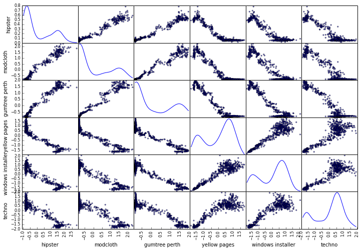

```python
# look at the relations
_ = pd.scatter_matrix(trend, figsize=(12,8), diagonal='kde')
```

# Titanic: Machine Learning from Disaster (kaggle.com)

Load the data, explore it and learn from it

```python
df = pd.read_csv('train.csv', header=0)
```

```python
df.head()
```

|  | PassengerId | Survived | Pclass | Name | Sex | Age | SibSp | Parch | Ticket | Fare | Cabin | Embarked |
| --- | --- | --- | --- | --- | --- | --- | --- | --- | --- | --- | --- | --- |
| 0 | 1 | 0 | 3 | Braund, Mr. Owen Harris | male | 22 | 1 | 0 | A/5 21171 | 7.2500 | NaN | S |
| 1 | 2 | 1 | 1 | Cumings, Mrs. John Bradley (Florence Briggs Th... | female | 38 | 1 | 0 | PC 17599 | 71.2833 | C85 | C |
| 2 | 3 | 1 | 3 | Heikkinen, Miss. Laina | female | 26 | 0 | 0 | STON/O2. 3101282 | 7.9250 | NaN | S |
| 3 | 4 | 1 | 1 | Futrelle, Mrs. Jacques Heath (Lily May Peel) | female | 35 | 1 | 0 | 113803 | 53.1000 | C123 | S |
| 4 | 5 | 0 | 3 | Allen, Mr. William Henry | male | 35 | 0 | 0 | 373450 | 8.0500 | NaN | S |

5 rows × 12 columns

Lets look at the data types here (this time they're heterogeneous)

```python
df.dtypes
```

```
PassengerId      int64
Survived         int64
Pclass           int64
Name            object
Sex             object
Age            float64
SibSp            int64
Parch            int64
Ticket          object
Fare           float64
Cabin           object
Embarked        object
dtype: object
```

We can also get a more verbose summary

```python
df.info()
```

```
<class 'pandas.core.frame.DataFrame'>
Int64Index: 891 entries, 0 to 890
Data columns (total 12 columns):
PassengerId    891 non-null int64
Survived       891 non-null int64
Pclass         891 non-null int64
Name           891 non-null object
Sex            891 non-null object
Age            714 non-null float64
SibSp          891 non-null int64
Parch          891 non-null int64
Ticket         891 non-null object
Fare           891 non-null float64
Cabin          204 non-null object
Embarked       889 non-null object
dtypes: float64(2), int64(5), object(5)
```

DataFrames can be grouped, like in SQL (*it sucked to be a young male on the titanic*)

```python
df_grouped = df.groupby(['Pclass', 'Sex'])
```

```python
df_grouped[['Age', 'Survived']].mean()
```

| Pclass | Sex | Age | Survived |
| --- | --- | --- | --- |
| 1 | female | 34.611765 | 0.968085 |
|  | male | 41.281386 | 0.368852 |
| 2 | female | 28.722973 | 0.921053 |
|  | male | 30.740707 | 0.157407 |
| 3 | female | 21.750000 | 0.500000 |
|  | male | 26.507589 | 0.135447 |

6 rows × 2 columns

Histograms are straightforward

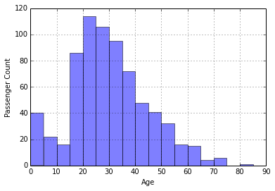

```python
ax = df['Age'].dropna().hist(bins=20, range=(0,100), alpha = .5)
ax.set_xlabel('Age')
ax.set_ylabel('Passenger Count')
```

So are boxplots

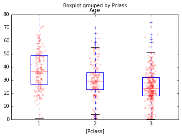

```python
bp = df.boxplot(column='Age', by='Pclass', grid=False)
for i in set(df.Pclass):
    y = df.Age[df.Pclass==i].dropna()
    # Add some random "jitter" to the x-axis
    x = np.random.normal(i, 0.04, size=len(y))
    plt.plot(x, y, 'r.', alpha=0.2)
```

If we want to do some learning on this data.. lets convert gender to a binary numeric

```python
df['isFemale'] = df['Sex'].map( {'female': 1, 'male': 0} ).astype(int)
df[['Sex','isFemale']].head()
```

|  | Sex | isFemale |
| --- | --- | --- |
| 0 | male | 0 |
| 1 | female | 1 |
| 2 | female | 1 |
| 3 | female | 1 |
| 4 | male | 0 |

5 rows × 2 columns

Find non-numeric columns so we can drop them later

```python
drop_cols = df.columns[df.dtypes.map(lambda x: x=='object')]
drop_cols
```

```
Index([u'Name', u'Sex', u'Ticket', u'Cabin', u'Embarked'], dtype='object')
```

```python
df.info()
```

```
<class 'pandas.core.frame.DataFrame'>
Int64Index: 891 entries, 0 to 890
Data columns (total 13 columns):
PassengerId    891 non-null int64
Survived       891 non-null int64
Pclass         891 non-null int64
Name           891 non-null object
Sex            891 non-null object
Age            714 non-null float64
SibSp          891 non-null int64
Parch          891 non-null int64
Ticket         891 non-null object
Fare           891 non-null float64
Cabin          204 non-null object
Embarked       889 non-null object
isFemale       891 non-null int64
dtypes: float64(2), int64(6), object(5)
```

Setup our data to learn from

```python
X = pd.DataFrame(df[[c for c in df.columns if c != 'Survived']])
X = X.drop(drop_cols, axis=1)
X = X.drop('PassengerId', axis=1)
y = df.Survived
print X.head()
```

```
   Pclass  Age  SibSp  Parch     Fare  isFemale
0       3   22      1      0   7.2500         0
1       1   38      1      0  71.2833         1
2       3   26      0      0   7.9250         1
3       1   35      1      0  53.1000         1
4       3   35      0      0   8.0500         0

[5 rows x 6 columns]
```

Have a quick look at the class distribution

```python
y.groupby(y.values).count()
```

```
0    549
1    342
dtype: int64
```

and fill in some NaNs for age

```python
X['Age'] = X.Age.fillna(X.Age.median())
```

# scikit-learn

## Machine Learning in Python

- Simple and efficient tools for data mining and data analysis
- Accessible to everybody, and reusable in various contexts
- Built on NumPy, SciPy, and matplotlib
- Open source, commercially usable - BSD license

### What is Machine Learning?

*Machine learning, a branch of artificial intelligence, concerns the construction and study of systems that can learn from data* **thanks wikipedia**

[figure not shown]

Prediction with scikit-learn is easy - who will survive?

```python
from sklearn.linear_model import LogisticRegression
from sklearn.metrics import accuracy_score as acc
```

```python
# create our classifier
clf = LogisticRegression()
# fit it to the data
clf.fit(X, y)
# and predict
preds = clf.predict(X)
res_acc = acc(y, preds)
print 'Accuracy Score: {:.2f}'.format(res_acc)
print 'Not too bad'
```

```
Accuracy Score: 0.80
Not too bad
```

## Cross-validation is a fairer performance estimate

[figure not shown]

```python
from sklearn.cross_validation import KFold
```

```python
cv = KFold(n=len(y), n_folds=5, shuffle=True)
preds = np.zeros_like(y)
for train, test in cv:
    clf = LogisticRegression()
    clf.fit(X.ix[train], y.ix[train])
    preds[test] = clf.predict(X.ix[test])
res_acc = acc(y, preds)
print 'Accuracy Score: {:.2f}'.format(res_acc)
```

```
Accuracy Score: 0.79
```

And cross-validation can be done more easily

```python
# scikits can actually take care of this for us
from sklearn.cross_validation import cross_val_score

# here
clf = LogisticRegression()
scores = cross_val_score(clf, X, y, cv=5, scoring='accuracy')
# to here

print scores
print("Accuracy: %0.2f (+/- %0.2f)" % (scores.mean(), scores.std() * 2))
```

```
[ 0.81564246  0.76966292  0.75842697  0.83707865  0.78651685]
Accuracy: 0.79 (+/- 0.06)
```

### dealing with categorical data

```python
df.Embarked.head()
```

```
0    S
1    C
2    S
3    S
4    S
Name: Embarked, dtype: object
```

```python
set(df.Embarked.fillna('O'))
```

```
{'C', 'O', 'Q', 'S'}
```

Use the LabelEncoder

```python
from sklearn import preprocessing
df.Embarked = df.Embarked.fillna('O')
le = preprocessing.LabelEncoder()
le.fit(df.Embarked.values)
le.classes_
```

```
array(['C', 'O', 'Q', 'S'], dtype=object)
```

```python
X['Embarked'] = le.transform(df.Embarked.values)
X.Embarked.head()
```

```
0    3
1    0
2    3
3    3
4    3
Name: Embarked, dtype: int64
```

### tuning classifier parameters

```python
for C in [0.001, 0.01, 0.1, 1, 10, 100]:
    clf = LogisticRegression(C=C, penalty='l1')
    scores = cross_val_score(clf, X, y, cv=5, scoring='accuracy')
    print("n_estimators: {:3.3f}\tAccuracy: {:.2f} (+/- {:.2f})"
          .format(C, scores.mean(), scores.std() * 2))
```

```
n_estimators: 0.001	Accuracy: 0.67 (+/- 0.03)
n_estimators: 0.010	Accuracy: 0.67 (+/- 0.03)
n_estimators: 0.100	Accuracy: 0.79 (+/- 0.05)
n_estimators: 1.000	Accuracy: 0.80 (+/- 0.06)
n_estimators: 10.000	Accuracy: 0.79 (+/- 0.04)
n_estimators: 100.000	Accuracy: 0.79 (+/- 0.04)
```

### Comparing classifiers is easy

```python
# normalise the data
from sklearn.preprocessing import StandardScaler
X = StandardScaler().fit_transform(X)
```

```python
from sklearn.linear_model import LogisticRegression
from sklearn.neighbors import KNeighborsClassifier
from sklearn.svm import SVC
from sklearn.tree import DecisionTreeClassifier
from sklearn.ensemble import RandomForestClassifier, AdaBoostClassifier
from sklearn.naive_bayes import GaussianNB
from sklearn.lda import LDA
from sklearn.qda import QDA

names = ["Nearest Neighbors", "Linear SVM", "RBF SVM", "Decision Tree",
         "Random Forest", "AdaBoost", "Naive Bayes", "LDA",
         "QDA", "Logistic Regression"]
classifiers = [
    KNeighborsClassifier(3),
    SVC(kernel="linear", C=0.025),
    SVC(gamma=2, C=1),
    DecisionTreeClassifier(),
    RandomForestClassifier(),
    AdaBoostClassifier(),
    GaussianNB(),
    LDA(),
    QDA(),
    LogisticRegression(class_weight='auto')]
```

```python
# fit each classifier and find the mean performance
res = []
for name, clf in zip(names, classifiers):
    scores = cross_val_score(clf, X, y, cv=5, scoring='accuracy')
    res.append(scores.mean())
```

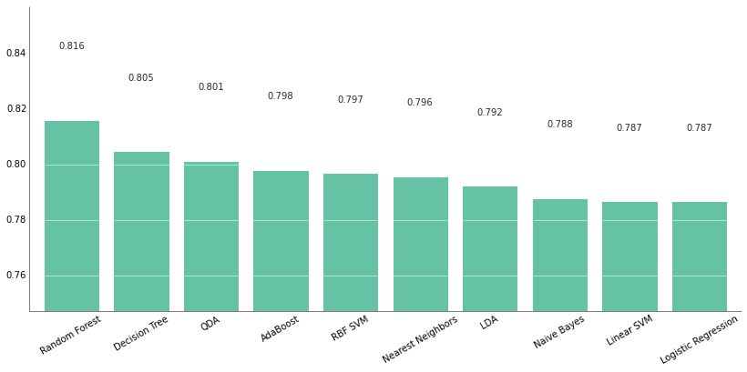

```python
import prettyplotlib as ppl
res = np.array(res)
names = np.array(names)
idx = np.argsort(res)[::-1]
fig, ax = plt.subplots(1, figsize=(14, 6))
ppl.bar(ax, np.arange(len(res)), res[idx], annotate=True,
        xticklabels=names[idx], grid='y')
plt.xticks(rotation=30)
_ = ax.set_ylim(res.min() * 0.95, res.max() * 1.05)
```

Models can be pickled

```python
# models can be saved
import pickle
s = pickle.dumps(clf)
```

## And there is a whole lot scikit-learn can do..

### supervised learning

### model evaluation

### unsupervised learning

### feature selection

### feature extraction

*by Andreas Mueller*

[figure not shown]